# Exemplo: dados qualitativos em FMI

# Ativando o pacote

Após a instalação do pacote é preciso ativa-lo. Para isso, deve-se utilizar a função `library` ou `require`

```r
library(MultivariateAnalysis)
```

# Abrindo o conjunto de dados

Posteriormente, deve-se carregar no R o conjunto de dados a serem analizados. Isso pode ser feito de diferentes formas.

Uma possibilidade é utilizando a função `read.table`. Neste exemplo vamos trabalhar com o banco de dados do pacote, o qual pode ser carregado com a função `data`.

Este exemplo trata-se de dados multicategóricos em Famílias de Meios Irmãos.

```r
data("Dados.FMI.Quali")
head(Dados.FMI.Quali)
```

```
#>   Parcela Tratamento Planta Bloco avaliador Angulodafolha Formatodolimbofoliar
#> 1      27    F11B3P2      1     1         1             1                    2
#> 2      27    F11B3P2      2     1         1             1                    6
#> 3      27    F11B3P2      3     1         1             2                    1
#> 4      27    F11B3P2      4     1         1             2                    1
#> 5      27    F11B3P2      5     1         1            NA                   NA
#> 6      27    F11B3P2      6     1         1             2                    2
#>   Divisaofoliar Divisaofoliarincisao Formatodoapice
#> 1             4                    4              4
#> 2             4                    2              4
#> 3             4                    3              6
#> 4             4                    3              6
#> 5            NA                   NA             NA
#> 6             4                    2              4
```

#Obtendo a porcentagem de cada classificação em nível de tratamento.

```r
Fator=Dados.FMI.Quali$Tratamento
DadosQuali=Dados.FMI.Quali[,6:10]
Dados2=ApplyDissimilaridade(Dados = DadosQuali,Factor = Fator)
(head(Dados2))
```

```
#>         Angulodafolha_1 Angulodafolha_2 Angulodafolha_3 Angulodafolha_4
#> F11B3P2       0.2181818       0.5272727       0.1454545      0.10909091
#> F11B3P4       0.2363636       0.3636364       0.3272727      0.07272727
#> F12B1P1       0.1509434       0.5660377       0.2830189      0.00000000
#> F12B1P2       0.1403509       0.5614035       0.2982456      0.00000000
#> F12B1P5       0.1020408       0.3877551       0.3469388      0.16326531
#> F12B2P2       0.2173913       0.5869565       0.1521739      0.04347826
#>         Angulodafolha_5 Formatodolimbofoliar_2 Formatodolimbofoliar_6
#> F11B3P2               0              0.5000000             0.03030303
#> F11B3P4               0              0.2096774             0.00000000
#> F12B1P1               0              0.2833333             0.00000000
#> F12B1P2               0              0.4218750             0.03125000
#> F12B1P5               0              0.3500000             0.00000000
#> F12B2P2               0              0.3877551             0.00000000
#>         Formatodolimbofoliar_1 Formatodolimbofoliar_3 Formatodolimbofoliar_5
#> F11B3P2              0.2575758              0.1666667             0.03030303
#> F11B3P4              0.4838710              0.2258065             0.08064516
#> F12B1P1              0.1833333              0.4666667             0.05000000
#> F12B1P2              0.1562500              0.3281250             0.04687500
#> F12B1P5              0.2500000              0.3333333             0.05000000
#> F12B2P2              0.3061224              0.1632653             0.10204082
#>         Formatodolimbofoliar_4 Formatodolimbofoliar_7 Divisaofoliar_4
#> F11B3P2             0.01515152                      0      0.56666667
#> F11B3P4             0.00000000                      0      0.03389831
#> F12B1P1             0.01666667                      0      0.00000000
#> F12B1P2             0.01562500                      0      0.15000000
#> F12B1P5             0.01666667                      0      0.00000000
#> F12B2P2             0.04081633                      0      0.04081633
#>         Divisaofoliar_2 Divisaofoliar_3 Divisaofoliar_5 Divisaofoliar_7
#> F11B3P2       0.3000000       0.1166667      0.01666667      0.00000000
#> F11B3P4       0.7966102       0.1694915      0.00000000      0.00000000
#> F12B1P1       0.6724138       0.3275862      0.00000000      0.00000000
#> F12B1P2       0.5666667       0.2666667      0.01666667      0.00000000
#> F12B1P5       0.6896552       0.2931034      0.00000000      0.01724138
#> F12B2P2       0.4693878       0.4693878      0.00000000      0.00000000
#>         Divisaofoliar_1 Divisaofoliar_0 Divisaofoliar_6 Divisaofoliarincisao_4
#> F11B3P2      0.00000000               0               0             0.45000000
#> F11B3P4      0.00000000               0               0             0.01666667
#> F12B1P1      0.00000000               0               0             0.00000000
#> F12B1P2      0.00000000               0               0             0.08333333
```

[output cut: 22 more lines]

```
#> F12B2P2                      0                      0                      0
#>         Formatodoapice_4 Formatodoapice_6 Formatodoapice_8 Formatodoapice_2
#> F11B3P2       0.37500000        0.6250000       0.00000000        0.0000000
#> F11B3P4       0.13725490        0.6470588       0.03921569        0.1764706
#> F12B1P1       0.07843137        0.6666667       0.09803922        0.1568627
#> F12B1P2       0.14000000        0.5600000       0.14000000        0.1600000
#> F12B1P5       0.01851852        0.5740741       0.14814815        0.2407407
#> F12B2P2       0.20000000        0.5777778       0.02222222        0.1777778
#>         Formatodoapice_1 Formatodoapice_5 Formatodoapice_0 Formatodoapice_3
#> F11B3P2       0.00000000                0                0                0
#> F11B3P4       0.00000000                0                0                0
#> F12B1P1       0.00000000                0                0                0
#> F12B1P2       0.00000000                0                0                0
#> F12B1P5       0.01851852                0                0                0
#> F12B2P2       0.02222222                0                0                0
```

# Obtenção de medidas de dissimilaridade

Muitas são as opções que este pacote oferece de medidas de dissimilaridade. Convidamos os usuários a ler o manual da funcao `Distancia` (`?Distancia`).

Para se ter diferentes medidas de dissimilaridade basta colocar o respectivo numero no argumento `Metodo` dentro da função `Distancia`:

### Dados quantitativos

1 = Distancia euclidiana.

2= Distancia euclidiana media.

3 = Quadrado da distancia euclidiana media.

4 = Distancia euclidiana padronizada.

5 = Distancia euclidiana padronizada media.

6 = Quadrado da distancia euclidiana padronizada media.

7 = Distancia de Mahalanobis.

8 = Distancia de Cole Rodgers.

```r
#distancia euclidiana padronizada
Dist=Distancia(Dados2,Metodo = 4)
```

Informações importantes podem ser obtidas dessa matriz com a função `SummaryDistancia`:

```r
resumo=SummaryDistancia(Dist)
```

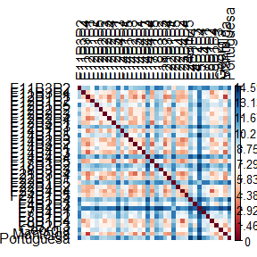

```r
resumo
```

```
#> _________________________________________________________________________
#> Tabela com o resumo da matriz dissimilaridade
#>            Medio Minimo Maximo   sd MaisProximo MaisDistante
#> F11B3P2    10.48   6.13  13.16 1.64     F22B1P5   Portuguesa
#> F11B3P4     7.20   4.05  12.40 1.98      F8B1P4       F5B1P4
#> F12B1P1     6.47   2.17  12.51 2.52    Manteiga       F5B1P4
#> F12B1P2     7.61   4.12  11.80 2.03     F12B2P4       F5B1P4
#> F12B1P5     9.16   6.76  13.85 1.71     F14B4P3       F5B1P4
#> F12B2P2     7.39   3.93  11.85 2.00     F22B1P1       F5B1P4
#> F12B2P3     7.41   4.28  11.86 1.91     F23B4P4       F5B1P4
#> F12B2P4     7.33   3.57  12.80 2.24     F12B1P1       F5B1P4
#> F12B3P1     6.95   3.35  12.60 2.17     F17B1P5       F5B1P4
#> F12B4P3    10.66   9.03  14.35 1.37     F12B3P1       F5B1P4
#> F14B1P1     7.24   3.90  10.92 2.04     F12B1P1       F5B1P4
#> F14B1P5     9.34   6.67  14.46 1.76     F12B3P1       F5B1P4
#> F14B2P3     6.86   3.56  12.37 2.25     F23B4P4       F5B1P4
#> F14B3P2     6.69   3.09  12.59 2.36     F17B1P5       F5B1P4
#> F14B4P1     7.99   6.00  12.55 1.78     F23B4P4       F5B1P4
#> F14B4P3     6.52   3.03  12.26 2.35    Manteiga       F5B1P4
#> F14B4P4    11.21   9.26  14.42 1.38     F14B1P1       F5B1P4
#> F17B1P5     6.54   3.09  12.07 2.20     F14B3P2       F5B1P4
#> F18B3P2    10.62   8.48  14.02 1.38     F17B1P5       F5B1P4
#> F18B3P3     9.59   7.69  14.05 1.58     F12B3P1       F5B1P4
#> F21B3P4     6.55   3.15  12.65 2.45     F14B3P2       F5B1P4
#> F22B1P1     7.16   3.93  12.42 2.17     F12B2P2       F5B1P4
#> F22B1P5    10.79   6.13  13.40 1.47     F11B3P2      F14B4P4
#> F22B4P2     7.15   4.58  12.82 2.11     F21B3P4       F5B1P4
#> F23B4P4     6.51   2.87  11.54 2.26      F8B1P4       F5B1P4
#> F24B1P5     7.06   4.36  11.85 2.00     F14B2P3       F5B1P4
#> F4B1P4     10.68   9.03  13.94 1.42     F14B4P3   Portuguesa
#> F4B2P3      8.67   5.99  12.99 1.72      F9B2P3       F5B1P4
#> F5B1P4     12.77   9.81  14.59 1.14     F22B1P5   Portuguesa
#> F7B4P1      9.44   7.15  14.32 1.70     F14B4P3       F5B1P4
#> F8B1P2      9.47   7.24  13.77 1.74     F14B4P3       F5B1P4
#> F8B1P4      7.21   2.87  12.34 2.14     F23B4P4       F5B1P4
#> F9B2P3      7.47   4.65  12.79 2.03    Manteiga       F5B1P4
#> Georgia     8.66   3.87  13.80 2.07  Portuguesa       F5B1P4
#> Manteiga    6.72   2.17  12.95 2.48     F12B1P1       F5B1P4
#> Portuguesa 10.30   3.87  14.59 2.05     Georgia       F5B1P4
#>
#> Menor Distancia: 2.169371
#> Maior Distancia: 14.58522
#> Media das Distancias: 8.330065
#> Amplitude das Distancias: 12.41585
#> Desvio Padrao das Distancias: 2.573037
#> Coeficiente de variacao das Distancias: 30.88856
#> Individuos mais proximos: F12B1P1 Manteiga
#> Individuos mais distantes: F5B1P4 Portuguesa
#> _________________________________________________________________________
```

A fim de resumir as informações da matriz de dissimilaridade a fim de melhorar a visualização da dissimilaridade, pode-se fazer um Dendrograma com o auxilio da função `Dendrograma`. Varios algoritimos podem ser utilizados para a construção deste Dendrograma. Para isso, deve-se indicar no argumento `Metodo`:

1 = Ligacao simples (Metodo do vizinho mais proximo).

2 = Ligacao completa (Metodo do vizinho distante).

3 = Ligacao media entre grupo (UPGMA).

4 = Metodo de Ward.

5 = Metodo de ward (d2).

6= Metodo da mediana (WPGMC).

7= Metodo do centroide (UPGMC).

8 = Metodo mcquitty (WPGMA).

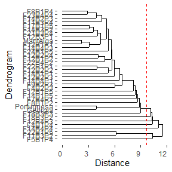

```r
#Dendrograma com o metodo UPGMA
Dendo=Dendrograma(Dist,Metodo=3)
```

```r
Dendo$SigCorrelCofenetica
```

```
#> Estimativa de correlacao:  0.9116587
#> P-valor obtido pelo teste Mantel:  0.001
#> Hipotese alternativa:  bilateral
```

```r
Dendo$MojenaCorte
```

[output not shown]

Adcionalmente, pode-se fazer o agrupamento Tocher com o auxilio da função `Tocher`:

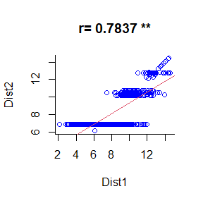

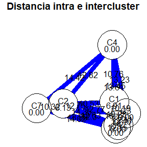

```r
#Dendrograma com o metodo UPGMA
To=Tocher(Dist)
```

```r
To$Tocher
```

```
#> $`cluster 1`
#>  [1] F12B1P1    Manteiga   F14B4P3    F14B3P2    F21B3P4    F17B1P5
#>  [7] F23B4P4    F12B3P1    F14B2P3    F22B4P2    F24B1P5    F8B1P4
#> [13] F11B3P4    F12B2P4    F14B1P1    F22B1P1    F12B2P2    F12B1P2
#> [19] F12B2P3    F9B2P3     F14B4P1    F4B2P3     Georgia    F12B1P5
#> [25] F14B1P5    F7B4P1     F8B1P2     F18B3P3    Portuguesa
#>
#> $`cluster 2`
#> [1] F11B3P2 F22B1P5
#>
#> $`cluster 3`
#> [1] F12B4P3
#>
#> $`cluster 4`
#> [1] F14B4P4
#>
#> $`cluster 5`
#> [1] F18B3P2
#>
#> $`cluster 6`
#> [1] F4B1P4
#>
#> $`cluster 7`
#> [1] F5B1P4
```

```r
To$DistanciaIntraInterCluster
```

```
#>           cluster 1 cluster 2 cluster 3 cluster 4 cluster 5 cluster 6 cluster 7
#> cluster 1  6.913665 10.525979  10.18662  10.76328  10.16810  10.23428  12.75033
#> cluster 2 10.525979  6.129233  12.76782  12.82102  12.30325  12.62523  10.32105
#> cluster 3 10.186625 12.767821   0.00000  13.23156  12.46421  12.11257  14.35269
#> cluster 4 10.763282 12.821023  13.23156   0.00000  13.60951  13.44901  14.42456
#> cluster 5 10.168100 12.303247  12.46421  13.60951   0.00000  12.14783  14.02431
#> cluster 6 10.234282 12.625225  12.11257  13.44901  12.14783   0.00000  13.88823
#> cluster 7 12.750326 10.321047  14.35269  14.42456  14.02431  13.88823   0.00000
```

```r
To$CorrelacaoCofenetica
```

```
#> Estimativa de correlacao:  0.7836556
#> P-valor obtido pelo teste Mantel:  0.001
#> Hipotese alternativa:  maior
```

Outra possibilidade é o estudo da dispersão da matriz de dissimilaridade pelas técnica de coordenadas principais:

```r
CO=CoordenadasPrincipais(Dist)
```

```
#> [1] 1
```

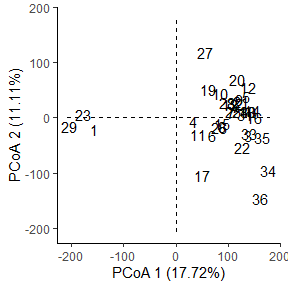

Logo, quando se tem dados quantitativos faz mais sentido utilizar os componentes principais que coordenadas principais em situações quando irá se considerar a distância euclidiana padronizada.